# **PROJECT DESCRIPTION**

## Problem Statement

- The dataset used in this project is originally from NIDDK. NIDDK (National Institute of Diabetes and Digestive and Kidney Diseases) research creates knowledge about and treatments for the most chronic, costly, and consequential diseases.
- The objective is to predict whether or not a patient has diabetes, based on certain diagnostic measurements included in the dataset.
- Build a model to accurately predict whether the patients in the dataset have diabetes or not.

## Dataset Description

The datasets consists of 8 medical predictor variables and a target variable (Outcome). Predictor variables includes the number of pregnancies the patient has had, their Glucose level, their BP, BMI, insulin level, Skinthickness, DPF and their age.

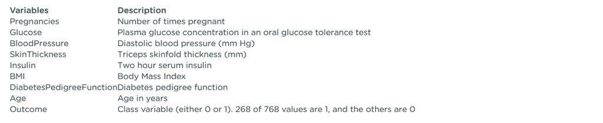

# **WEEK 1 : Descriptive Analysis**

## **Loading the Libraries**

```python
import pandas as pd
import numpy as np
import matplotlib.pyplot as plt
import seaborn as sns

import warnings
warnings.filterwarnings('ignore')

%matplotlib inline
```

## **1. Importing the dataset and understanding the variables:**

### Perform descriptive analysis. Understand the variables and their corresponding values. On the columns below, a value of zero does not make sense and thus indicates missing value:

- Glucose
- BloodPressure
- SkinThickness
- Insulin
- BMI

```python
data = pd.read_csv('health care diabetes.csv')
```

```python
# Printing the 1st few rows to take a look at the dataset

data.head()
```

|  | Pregnancies | Glucose | BloodPressure | SkinThickness | Insulin | BMI | DiabetesPedigreeFunction | Age | Outcome |
| --- | --- | --- | --- | --- | --- | --- | --- | --- | --- |
| 0 | 6 | 148 | 72 | 35 | 0 | 33.6 | 0.627 | 50 | 1 |
| 1 | 1 | 85 | 66 | 29 | 0 | 26.6 | 0.351 | 31 | 0 |
| 2 | 8 | 183 | 64 | 0 | 0 | 23.3 | 0.672 | 32 | 1 |
| 3 | 1 | 89 | 66 | 23 | 94 | 28.1 | 0.167 | 21 | 0 |
| 4 | 0 | 137 | 40 | 35 | 168 | 43.1 | 2.288 | 33 | 1 |

```python
data.info()
```

```
<class 'pandas.core.frame.DataFrame'>
RangeIndex: 768 entries, 0 to 767
Data columns (total 9 columns):
 #   Column                    Non-Null Count  Dtype
---  ------                    --------------  -----
 0   Pregnancies               768 non-null    int64
 1   Glucose                   768 non-null    int64
 2   BloodPressure             768 non-null    int64
 3   SkinThickness             768 non-null    int64
 4   Insulin                   768 non-null    int64
 5   BMI                       768 non-null    float64
 6   DiabetesPedigreeFunction  768 non-null    float64
 7   Age                       768 non-null    int64
 8   Outcome                   768 non-null    int64
dtypes: float64(2), int64(7)
memory usage: 54.1 KB
```

```python
data.describe().transpose()
```

|  | count | mean | std | min | 25% | 50% | 75% | max |
| --- | --- | --- | --- | --- | --- | --- | --- | --- |
| Pregnancies | 768.0 | 3.845052 | 3.369578 | 0.000 | 1.00000 | 3.0000 | 6.00000 | 17.00 |
| Glucose | 768.0 | 120.894531 | 31.972618 | 0.000 | 99.00000 | 117.0000 | 140.25000 | 199.00 |
| BloodPressure | 768.0 | 69.105469 | 19.355807 | 0.000 | 62.00000 | 72.0000 | 80.00000 | 122.00 |
| SkinThickness | 768.0 | 20.536458 | 15.952218 | 0.000 | 0.00000 | 23.0000 | 32.00000 | 99.00 |
| Insulin | 768.0 | 79.799479 | 115.244002 | 0.000 | 0.00000 | 30.5000 | 127.25000 | 846.00 |
| BMI | 768.0 | 31.992578 | 7.884160 | 0.000 | 27.30000 | 32.0000 | 36.60000 | 67.10 |
| DiabetesPedigreeFunction | 768.0 | 0.471876 | 0.331329 | 0.078 | 0.24375 | 0.3725 | 0.62625 | 2.42 |
| Age | 768.0 | 33.240885 | 11.760232 | 21.000 | 24.00000 | 29.0000 | 41.00000 | 81.00 |
| Outcome | 768.0 | 0.348958 | 0.476951 | 0.000 | 0.00000 | 0.0000 | 1.00000 | 1.00 |

### **Insights from Descriptive Analysis**

- There are 768 observations with 9 variables.
- Average Age of Patients is 33 with min being 21 and max 81. Avg. value of the other predictor variables are Preg = 3, Glucose = 120, BP = 69, ST=20.5, Insulin = 79.7, BMI = 31 DPF = 0.47
- "Outcome" is the target variable.
- Another point to note is, we have "0" as minimum value for the columns: Glucose, BloodPressure, SkinThickness, Insulin and BMI.

  Clearly, these values do not make sense and thus indicate missing value. So, we need to treat them.

```python
# Observing the Variation in variables

data.apply (np.std)
```

```
Pregnancies                   3.367384
Glucose                      31.951796
BloodPressure                19.343202
SkinThickness                15.941829
Insulin                     115.168949
BMI                           7.879026
DiabetesPedigreeFunction      0.331113
Age                          11.752573
Outcome                       0.476641
dtype: float64
```

## **2. Exploring the variables and Treating missing values:**

### Visually explore these variables using histograms. Treat the missing values accordingly.

```
array([[<AxesSubplot:title={'center':'Pregnancies'}>,
        <AxesSubplot:title={'center':'Glucose'}>,
        <AxesSubplot:title={'center':'BloodPressure'}>],
       [<AxesSubplot:title={'center':'SkinThickness'}>,
        <AxesSubplot:title={'center':'Insulin'}>,
        <AxesSubplot:title={'center':'BMI'}>],
       [<AxesSubplot:title={'center':'DiabetesPedigreeFunction'}>,
        <AxesSubplot:title={'center':'Age'}>,
        <AxesSubplot:title={'center':'Outcome'}>]], dtype=object)
```

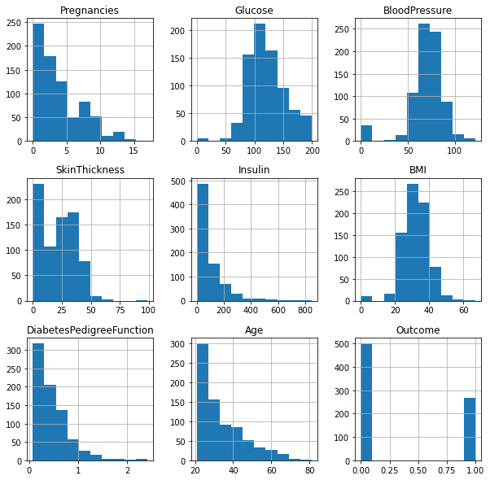

```python
## Visualising the data with histogram

data.hist(figsize=(10,10))
```

```python
## Treating missing values: (replacing "0" with the mean of the class)

data['Glucose']=data['Glucose'].replace(0,data['Glucose'].mean())
data['BloodPressure']=data['BloodPressure'].replace(0,data['BloodPressure'].mean())
data['SkinThickness']=data['SkinThickness'].replace(0,data['SkinThickness'].mean())
data['Insulin']=data['Insulin'].replace(0,data['Insulin'].mean())
data['BMI']=data['BMI'].replace(0,data['BMI'].mean())
```

## **3. Plotting the data types and the count of variables:**

### There are integer and float data type variables in this dataset. Create a count (frequency) plot describing the data types and the count of variables.

```python
data.dtypes
```

```
Pregnancies                   int64
Glucose                     float64
BloodPressure               float64
SkinThickness               float64
Insulin                     float64
BMI                         float64
DiabetesPedigreeFunction    float64
Age                           int64
Outcome                       int64
dtype: object
```

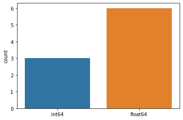

```python
## Visualising using countplot (frequency plot):

sns.countplot(data.dtypes.map(str))
plt.show()
```

### **Data types Description**

```python
# Let's take a look at our dataset at the end of WEEK -1

data.head()
```

|  | Pregnancies | Glucose | BloodPressure | SkinThickness | Insulin | BMI | DiabetesPedigreeFunction | Age | Outcome |
| --- | --- | --- | --- | --- | --- | --- | --- | --- | --- |
| 0 | 6 | 148.0 | 72.0 | 35.000000 | 79.799479 | 33.6 | 0.627 | 50 | 1 |
| 1 | 1 | 85.0 | 66.0 | 29.000000 | 79.799479 | 26.6 | 0.351 | 31 | 0 |
| 2 | 8 | 183.0 | 64.0 | 20.536458 | 79.799479 | 23.3 | 0.672 | 32 | 1 |
| 3 | 1 | 89.0 | 66.0 | 23.000000 | 94.000000 | 28.1 | 0.167 | 21 | 0 |
| 4 | 0 | 137.0 | 40.0 | 35.000000 | 168.000000 | 43.1 | 2.288 | 33 | 1 |

```python
data.to_excel('Diabetes Detection Dataset.xlsx', index = False)
```

### We can observe that the values that indicated 0 have changed, representing the mean of the class.

# **WEEK 2 : Exploratory Analysis**

## **1. Checking the balance of the Data and correlation between variables :**

### Check the balance of the data by plotting the count of outcomes by their value. Describe your findings and plan future course of action.

```
Count of class is:
 0    500
1    268
Name: Outcome, dtype: int64
```

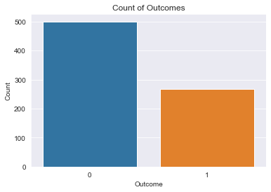

```python
# Checking the balance of the data

sns.set_style('darkgrid')
sns.countplot(data['Outcome'])
plt.title("Count of Outcomes")
plt.xlabel('Outcome')
plt.ylabel("Count")
print("Count of class is:\n",data['Outcome'].value_counts())
```

### **Finding** :- We can see that there is an imbalance in the data, and the outcome is biased towards 0 (no diabetes).

### **Future Action** :- We'll balance the data using SMOTE before data modelling. ( In WEEK-3 )

## **2. Understanding the relationship between varaiables**

### Create scatter charts between the pair of variables to understand the relationships. Describe your findings.

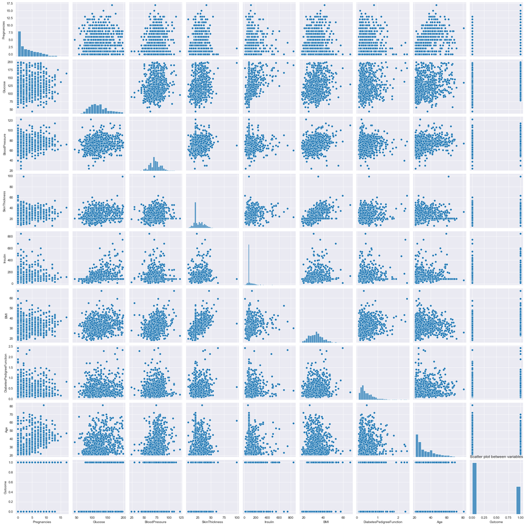

```python
## Visualising using scatter plot

sns.pairplot(data)
plt.title('Scatter plot between variables')
```

### **Findings from the scatter plot:**

We can see from the plot that, there is not much multicolinearity among features,

but there seems a slight positive correlation between

- Skin thickness and BMI,
- Pregnancies and age.

  We will explore more when analyzing correlation.

## **3. Correlation Analysis**

### Perform correlation analysis. Visually explore it using a heat map.

```python
data.corr()
```

|  | Pregnancies | Glucose | BloodPressure | SkinThickness | Insulin | BMI | DiabetesPedigreeFunction | Age | Outcome |
| --- | --- | --- | --- | --- | --- | --- | --- | --- | --- |
| Pregnancies | 1.000000 | 0.127964 | 0.208984 | 0.013376 | -0.018082 | 0.021546 | -0.033523 | 0.544341 | 0.221898 |
| Glucose | 0.127964 | 1.000000 | 0.219666 | 0.160766 | 0.396597 | 0.231478 | 0.137106 | 0.266600 | 0.492908 |
| BloodPressure | 0.208984 | 0.219666 | 1.000000 | 0.134155 | 0.010926 | 0.281231 | 0.000371 | 0.326740 | 0.162986 |
| SkinThickness | 0.013376 | 0.160766 | 0.134155 | 1.000000 | 0.240361 | 0.535703 | 0.154961 | 0.026423 | 0.175026 |
| Insulin | -0.018082 | 0.396597 | 0.010926 | 0.240361 | 1.000000 | 0.189856 | 0.157806 | 0.038652 | 0.179185 |
| BMI | 0.021546 | 0.231478 | 0.281231 | 0.535703 | 0.189856 | 1.000000 | 0.153508 | 0.025748 | 0.312254 |
| DiabetesPedigreeFunction | -0.033523 | 0.137106 | 0.000371 | 0.154961 | 0.157806 | 0.153508 | 1.000000 | 0.033561 | 0.173844 |
| Age | 0.544341 | 0.266600 | 0.326740 | 0.026423 | 0.038652 | 0.025748 | 0.033561 | 1.000000 | 0.238356 |
| Outcome | 0.221898 | 0.492908 | 0.162986 | 0.175026 | 0.179185 | 0.312254 | 0.173844 | 0.238356 | 1.000000 |

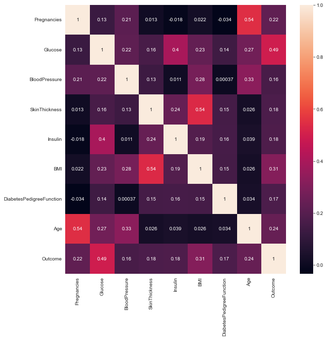

```python
## Visualising using correlation heatmap

plt.figure(figsize=(10,10))
sns.heatmap(data.corr(), annot=True)
```

### As observed there is a slight positive correlation between,

- Skin thickness and BMI,
- Pregnancies and age.

# **WEEK 3 : Predictive Analysis**

## **1. Data Validation:**

### Devise strategies for model building. It is important to decide the right validation framework. Express your thought process.

```python
# Assigning the variables

x = data.iloc[:,:-1].values
y = data.iloc[:,-1].values
```

```python
## NORMALISING the DATA :

# define columns to normalize
x = data.iloc[:,:-1]

#normalize values in first two columns only
data.iloc[:,:-1] = (x-x.min())/ (x.max() - x.min())

data.head()
```

|  | Pregnancies | Glucose | BloodPressure | SkinThickness | Insulin | BMI | DiabetesPedigreeFunction | Age | Outcome |
| --- | --- | --- | --- | --- | --- | --- | --- | --- | --- |
| 0 | 0.352941 | 0.670968 | 0.489796 | 0.304348 | 0.079086 | 0.314928 | 0.234415 | 0.483333 | 1 |
| 1 | 0.058824 | 0.264516 | 0.428571 | 0.239130 | 0.079086 | 0.171779 | 0.116567 | 0.166667 | 0 |
| 2 | 0.470588 | 0.896774 | 0.408163 | 0.147135 | 0.079086 | 0.104294 | 0.253629 | 0.183333 | 1 |
| 3 | 0.058824 | 0.290323 | 0.428571 | 0.173913 | 0.096154 | 0.202454 | 0.038002 | 0.000000 | 0 |
| 4 | 0.000000 | 0.600000 | 0.163265 | 0.304348 | 0.185096 | 0.509202 | 0.943638 | 0.200000 | 1 |

To understand model performance, dividing the dataset into a training set and a test set is a good strategy.

```python
## Splitting the data into Train and Test data

from sklearn.model_selection import train_test_split
x_train,x_test,y_train,y_test = train_test_split(x, y, test_size=0.20, random_state=40)
```

```python
## SCALING the DATA before applying SMOTE:

from sklearn.preprocessing import StandardScaler
sc = StandardScaler()

x_train = sc.fit_transform(x_train)
x_test = sc.transform (x_test)
```

```python
print(x_train.shape)
print(x_test.shape)
print(y_train.shape)
print(y_test.shape)
```

```
(614, 8)
(154, 8)
(614,)
(154,)
```

### **Balancing the data using SMOTE:**

```python
pip install imblearn
```

```python
from collections import Counter

counter = Counter(y_train)
print('Before', counter)

## Upsampling the train data using SMOTE

from imblearn import under_sampling, over_sampling
from imblearn.over_sampling import SMOTE
sm = SMOTE()
X_train , Y_train = sm.fit_resample(x_train, y_train)

counter = Counter(Y_train)
print('After', counter)
```

```
Before Counter({0: 405, 1: 209})
After Counter({0: 405, 1: 405})
```

### **Strategies for model building:**

- For Data Validation, we have
  - normalised the data,
  - applied train test split and then
  - upsampled the train data using SMOTE to balance the class of outcomes.
- For Data Modelling, All the variables in the data is numerical. And also, as we observed in the correlation analysis, the varaiables are linearly dependent on the target. In such case,
  - Logistic Regression is the best classification algorithm to apply.
- We will also apply
  - Decision Tree Classifier
  - Random Forrest Classifier(Ensemble Learning),
  - Support Vector Classifier and
  - KNN.
- For Model Validation, we will use parameters like
  - Sensitivity
  - Specificity
  - AUC (ROC curve) and
  - Confusion matrix
- We will also use other metrics like
  - Accuracy score
  - Precision score
  - Recall score and
  - F1 score while building the model.

## **2. Data Modelling:**

### - Apply an appropriate classification algorithm to build a model.

### - Compare various models with the results from KNN algorithm.

## **Logistic Regression**

```python
from sklearn.linear_model import LogisticRegression

lr = LogisticRegression()
lr.fit(X_train,Y_train)
```

```
LogisticRegression()
```

```python
lr_pred = lr.predict(x_test)
lr_pred
```

```
array([1, 1, 1, 0, 0, 0, 1, 1, 0, 0, 1, 1, 0, 0, 0, 1, 0, 0, 1, 1, 1, 0,
       0, 1, 1, 0, 1, 0, 1, 1, 0, 0, 0, 1, 0, 1, 0, 1, 1, 1, 1, 1, 0, 0,
       0, 1, 0, 0, 1, 0, 0, 1, 0, 1, 1, 0, 0, 1, 0, 0, 0, 0, 0, 1, 1, 0,
       1, 1, 1, 0, 0, 0, 0, 0, 1, 1, 0, 0, 1, 1, 0, 1, 0, 0, 0, 0, 0, 0,
       1, 1, 1, 0, 1, 0, 0, 1, 0, 0, 0, 0, 0, 0, 1, 0, 0, 0, 1, 0, 0, 0,
       1, 1, 1, 0, 0, 1, 0, 0, 1, 1, 1, 0, 0, 0, 0, 0, 1, 1, 1, 0, 0, 0,
       0, 0, 1, 0, 0, 0, 0, 1, 0, 0, 0, 1, 1, 1, 0, 1, 0, 0, 1, 1, 0, 0],
      dtype=int64)
```

```python
from sklearn import metrics
from sklearn.metrics import classification_report, precision_score, recall_score, accuracy_score, f1_score, confusion_matrix
```

```python
print("Accuracy of the model is :", round(accuracy_score(y_test,lr_pred),2))
print("Precision of the model is :", round(precision_score(y_test,lr_pred),2))
print("Recall of the model is :", round(recall_score(y_test,lr_pred),2))
print("F1 of the model is :", round(f1_score(y_test,lr_pred),2))
```

```
Accuracy of the model is : 0.75
Precision of the model is : 0.66
Recall of the model is : 0.71
F1 of the model is : 0.68
```

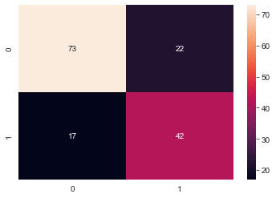

```python
# Evaluating with confusion matrix

cm = confusion_matrix (y_test, lr_pred)
sns.heatmap (cm, annot=True)
```

## **Decision Tree Classifier**

```python
from sklearn.tree import DecisionTreeClassifier

dt = DecisionTreeClassifier(max_depth=3)
dt.fit(X_train,Y_train)
```

```
DecisionTreeClassifier(max_depth=3)
```

```python
dt_pred = dt.predict(x_test)
dt_pred
```

```
array([1, 1, 1, 0, 0, 0, 1, 1, 0, 1, 1, 1, 0, 1, 0, 1, 1, 0, 1, 1, 0, 0,
       1, 1, 1, 0, 1, 0, 1, 1, 0, 0, 0, 1, 1, 1, 0, 1, 1, 1, 1, 1, 0, 0,
       0, 1, 0, 0, 1, 1, 0, 1, 0, 1, 1, 0, 0, 1, 0, 1, 0, 0, 0, 1, 1, 1,
       1, 1, 1, 0, 0, 0, 0, 0, 1, 1, 1, 0, 1, 1, 0, 1, 0, 0, 0, 0, 1, 1,
       1, 1, 1, 0, 0, 0, 1, 1, 0, 0, 0, 0, 0, 0, 1, 0, 0, 1, 1, 0, 0, 0,
       1, 1, 1, 0, 0, 1, 0, 0, 1, 1, 1, 0, 1, 0, 1, 0, 1, 1, 1, 0, 0, 0,
       0, 0, 1, 0, 1, 0, 1, 1, 0, 0, 1, 1, 1, 1, 0, 1, 0, 0, 1, 0, 0, 0],
      dtype=int64)
```

```python
print("Accuracy of the model is :", round(accuracy_score(y_test,dt_pred),2))
print("Precision of the model is :", round(precision_score(y_test,dt_pred),2))
print("Recall of the model is :", round(recall_score(y_test,dt_pred),2))
print("F1 of the model is :", round(f1_score(y_test,dt_pred),2))
```

```
Accuracy of the model is : 0.73
Precision of the model is : 0.61
Recall of the model is : 0.81
F1 of the model is : 0.7
```

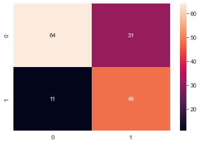

```python
# Evaluating with confusion matrix

cm = confusion_matrix (y_test, dt_pred)
sns.heatmap (cm, annot=True)
```

## **Random Forrest Classifier (Ensemble)**

```python
from sklearn.ensemble import RandomForestClassifier

rf = RandomForestClassifier(n_estimators=100, max_depth=35)
rf.fit(X_train,Y_train)
```

```
RandomForestClassifier(max_depth=35)
```

```python
rf_pred = rf.predict(x_test)
rf_pred
```

```
array([1, 0, 1, 0, 0, 0, 1, 1, 0, 0, 1, 1, 0, 0, 0, 1, 0, 0, 1, 0, 0, 0,
       0, 1, 1, 0, 1, 0, 1, 1, 0, 1, 0, 1, 0, 0, 0, 0, 1, 1, 1, 1, 0, 0,
       0, 0, 0, 0, 1, 0, 0, 0, 0, 1, 1, 0, 0, 1, 1, 0, 0, 0, 0, 1, 0, 0,
       1, 0, 1, 0, 0, 0, 1, 0, 1, 1, 0, 0, 1, 1, 0, 0, 0, 0, 0, 0, 0, 1,
       1, 0, 1, 0, 1, 0, 0, 1, 0, 0, 0, 0, 0, 0, 0, 0, 0, 0, 1, 0, 0, 0,
       1, 0, 1, 0, 0, 0, 0, 0, 1, 0, 0, 0, 1, 0, 0, 0, 1, 1, 1, 0, 0, 0,
       0, 0, 1, 1, 0, 0, 1, 1, 0, 0, 1, 0, 1, 1, 0, 1, 0, 0, 1, 0, 0, 0],
      dtype=int64)
```

```python
print("Accuracy of the model is :", round(accuracy_score(y_test,rf_pred),2))
print("Precision of the model is :", round(precision_score(y_test,rf_pred),2))
print("Recall of the model is :", round(recall_score(y_test,rf_pred),2))
print("F1 of the model is :", round(f1_score(y_test,rf_pred),2))
```

```
Accuracy of the model is : 0.75
Precision of the model is : 0.69
Recall of the model is : 0.63
F1 of the model is : 0.65
```

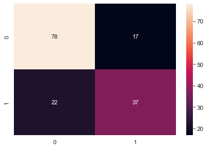

```python
# Evaluating with confusion matrix

cm = confusion_matrix (y_test, rf_pred)
sns.heatmap (cm, annot=True)
```

## **Support Vector Classifier**

```python
from sklearn.svm import SVC

svc = SVC(kernel='rbf',random_state=0,probability=True,C=1)
svc.fit(X_train,Y_train)
```

```
SVC(C=1, probability=True, random_state=0)
```

```python
svc_pred = svc.predict(x_test)
svc_pred
```

```
array([0, 1, 1, 0, 0, 0, 1, 1, 0, 0, 1, 1, 0, 0, 0, 1, 0, 0, 1, 0, 1, 0,
       0, 1, 1, 0, 1, 0, 1, 1, 0, 1, 0, 1, 1, 1, 1, 1, 1, 1, 1, 1, 0, 0,
       0, 0, 1, 0, 1, 1, 0, 0, 0, 1, 1, 0, 0, 1, 1, 1, 0, 0, 0, 1, 0, 1,
       0, 1, 1, 0, 0, 1, 1, 0, 0, 1, 0, 0, 1, 1, 0, 1, 0, 0, 0, 0, 0, 1,
       1, 0, 1, 0, 1, 0, 0, 1, 0, 0, 0, 0, 0, 0, 1, 0, 0, 0, 1, 0, 0, 0,
       1, 0, 1, 0, 0, 1, 0, 0, 1, 0, 1, 0, 1, 0, 0, 0, 1, 1, 1, 0, 0, 0,
       0, 0, 1, 1, 0, 0, 1, 1, 0, 0, 1, 1, 1, 1, 0, 1, 0, 0, 1, 1, 0, 0],
      dtype=int64)
```

```python
print("Accuracy of the model is :", round(accuracy_score(y_test,svc_pred),2))
print("Precision of the model is :", round(precision_score(y_test,svc_pred),2))
print("Recall of the model is :", round(recall_score(y_test,svc_pred),2))
print("F1 of the model is :", round(f1_score(y_test,svc_pred),2))
```

```
Accuracy of the model is : 0.71
Precision of the model is : 0.61
Recall of the model is : 0.71
F1 of the model is : 0.66
```

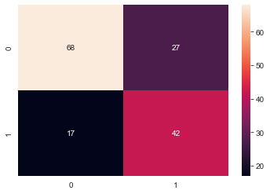

```python
# Evaluating with confusion matrix

cm = confusion_matrix (y_test, svc_pred)
sns.heatmap (cm, annot=True)
```

## **KNN Classifier**

```python
from sklearn.neighbors import KNeighborsClassifier

knn = KNeighborsClassifier(n_neighbors=5, metric='manhattan')
knn.fit(X_train, Y_train)
```

```
KNeighborsClassifier(metric='manhattan')
```

```python
knn_pred = knn.predict(x_test)
knn_pred
```

```
array([0, 1, 1, 0, 0, 0, 1, 1, 0, 0, 1, 1, 0, 0, 0, 1, 0, 0, 1, 1, 1, 0,
       1, 0, 1, 0, 1, 1, 1, 1, 0, 1, 0, 1, 1, 1, 0, 0, 1, 1, 1, 1, 0, 0,
       0, 0, 1, 0, 0, 0, 1, 0, 0, 1, 1, 1, 0, 1, 1, 1, 0, 0, 0, 1, 0, 0,
       0, 1, 1, 1, 0, 0, 1, 0, 1, 1, 0, 0, 1, 1, 0, 0, 0, 0, 0, 1, 0, 1,
       1, 0, 1, 0, 0, 0, 0, 0, 0, 0, 1, 0, 0, 0, 0, 0, 1, 1, 1, 0, 0, 0,
       1, 0, 1, 0, 0, 0, 0, 0, 1, 0, 1, 0, 1, 0, 0, 0, 1, 1, 1, 0, 0, 0,
       0, 0, 1, 1, 0, 0, 0, 1, 0, 0, 0, 0, 1, 1, 0, 1, 0, 0, 1, 0, 0, 0],
      dtype=int64)
```

```python
print("Accuracy of the model is :", round(accuracy_score(y_test,knn_pred),2))
print("Precision of the model is :", round(precision_score(y_test,knn_pred),2))
print("Recall of the model is :", round(recall_score(y_test,knn_pred),2))
print("F1 of the model is :", round(f1_score(y_test,knn_pred),2))
```

```
Accuracy of the model is : 0.68
Precision of the model is : 0.58
Recall of the model is : 0.63
F1 of the model is : 0.6
```

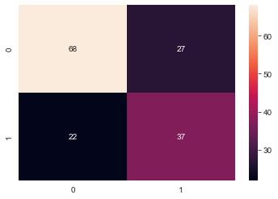

```python
# Evaluating with confusion matrix

cm = confusion_matrix (y_test, knn_pred)
sns.heatmap (cm, annot=True)
```

## **3. Classification report:**

### Create a classification report by analyzing sensitivity, specificity, AUC (ROC curve), etc.

## **Logistic Regression**

```
 Classification Report::
              precision    recall  f1-score   support

           0       0.81      0.77      0.79        95
           1       0.66      0.71      0.68        59

    accuracy                           0.75       154
   macro avg       0.73      0.74      0.74       154
weighted avg       0.75      0.75      0.75       154
```

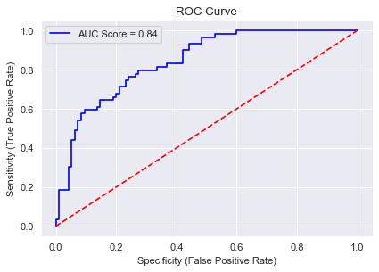

```python
print("\n","Classification Report::")
print(metrics.classification_report(y_test, lr_pred),'\n')

lr_prob = lr.predict_proba(x_test)
lr_prob1 = lr_prob[:,1]
fpr,tpr,thresh = metrics.roc_curve(y_test, lr_prob1)
roc_auc_lr = metrics.auc(fpr,tpr)
plt.figure(dpi=80)
plt.title("ROC Curve")
plt.xlabel('Specificity (False Positive Rate)')
plt.ylabel('Sensitivity (True Positive Rate)')
plt.plot(fpr,tpr,'b',label='AUC Score = %0.2f'%roc_auc_lr)
plt.plot(fpr,fpr,'r--',color='red')
plt.legend()
```

## **Decision Tree Classifier**

```
 Classification Report::
              precision    recall  f1-score   support

           0       0.85      0.67      0.75        95
           1       0.61      0.81      0.70        59

    accuracy                           0.73       154
   macro avg       0.73      0.74      0.72       154
weighted avg       0.76      0.73      0.73       154
```

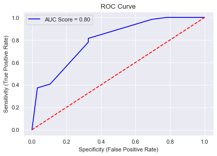

```python
print("\n","Classification Report::")
print(metrics.classification_report(y_test, dt_pred),'\n')

dt_prob = dt.predict_proba(x_test)
dt_prob1 = dt_prob[:,1]
fpr,tpr,thresh = metrics.roc_curve(y_test, dt_prob1)
roc_auc_dt = metrics.auc(fpr,tpr)
plt.figure(dpi=80)
plt.title("ROC Curve")
plt.xlabel('Specificity (False Positive Rate)')
plt.ylabel('Sensitivity (True Positive Rate)')
plt.plot(fpr,tpr,'b',label='AUC Score = %0.2f'%roc_auc_dt)
plt.plot(fpr,fpr,'r--',color='red')
plt.legend()
```

## **Random Forrest Classifier (Ensemble)**

```
 Classification Report::
              precision    recall  f1-score   support

           0       0.78      0.82      0.80        95
           1       0.69      0.63      0.65        59

    accuracy                           0.75       154
   macro avg       0.73      0.72      0.73       154
weighted avg       0.74      0.75      0.74       154
```

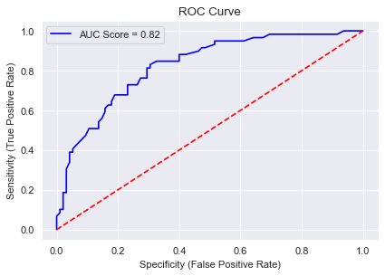

```python
print("\n","Classification Report::")
print(metrics.classification_report(y_test, rf_pred),'\n')

rf_prob = rf.predict_proba(x_test)
rf_prob1 = rf_prob[:,1]
fpr,tpr,thresh = metrics.roc_curve(y_test, rf_prob1)
roc_auc_rf = metrics.auc(fpr,tpr)
plt.figure(dpi=80)
plt.title("ROC Curve")
plt.xlabel('Specificity (False Positive Rate)')
plt.ylabel('Sensitivity (True Positive Rate)')
plt.plot(fpr,tpr,'b',label='AUC Score = %0.2f'%roc_auc_rf)
plt.plot(fpr,fpr,'r--',color='red')
plt.legend()
```

## **Support Vector Classifier**

```
 Classification Report::
              precision    recall  f1-score   support

           0       0.80      0.72      0.76        95
           1       0.61      0.71      0.66        59

    accuracy                           0.71       154
   macro avg       0.70      0.71      0.71       154
weighted avg       0.73      0.71      0.72       154
```

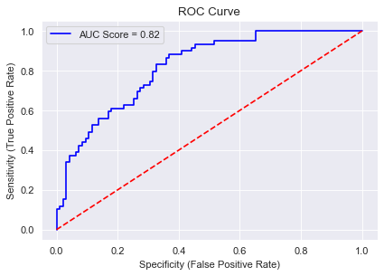

```python
print("\n","Classification Report::")
print(metrics.classification_report(y_test, svc_pred),'\n')

svc_prob = svc.predict_proba(x_test)
svc_prob1 = svc_prob[:,1]
fpr,tpr,thresh = metrics.roc_curve(y_test, svc_prob1)
roc_auc_svc = metrics.auc(fpr,tpr)
plt.figure(dpi=80)
plt.title("ROC Curve")
plt.xlabel('Specificity (False Positive Rate)')
plt.ylabel('Sensitivity (True Positive Rate)')
plt.plot(fpr,tpr,'b',label='AUC Score = %0.2f'%roc_auc_svc)
plt.plot(fpr,fpr,'r--',color='red')
plt.legend()
```

## **KNN Classifier**

```
 Classification Report::
              precision    recall  f1-score   support

           0       0.76      0.72      0.74        95
           1       0.58      0.63      0.60        59

    accuracy                           0.68       154
   macro avg       0.67      0.67      0.67       154
weighted avg       0.69      0.68      0.68       154
```

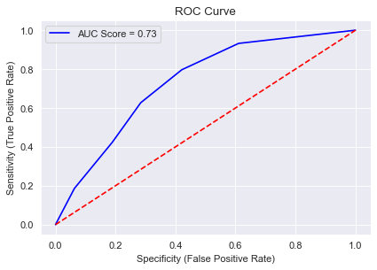

```python
print("\n","Classification Report::")
print(metrics.classification_report(y_test, knn_pred),'\n')

knn_prob = knn.predict_proba(x_test)
knn_prob1 = knn_prob[:,1]
fpr,tpr,thresh = metrics.roc_curve(y_test, knn_prob1)
roc_auc_knn = metrics.auc(fpr,tpr)
plt.figure(dpi=80)
plt.title("ROC Curve")
plt.xlabel('Specificity (False Positive Rate)')
plt.ylabel('Sensitivity (True Positive Rate)')
plt.plot(fpr,tpr,'b',label='AUC Score = %0.2f'%roc_auc_knn)
plt.plot(fpr,fpr,'r--',color='red')
plt.legend()
```

### **Insights from Classification report and Analysis:**

- We can see from the ROC-AUC plots that, considering the AUC Score of the models - Logistic Regression and RandomForrest(Ensemble) are our best performing models.
- Let's make the model better by searching for parameters and adjusting using a GridSearch!

## **GridSearchCV**

```python
print(lr.get_params().keys())
```

```
dict_keys(['C', 'class_weight', 'dual', 'fit_intercept', 'intercept_scaling', 'l1_ratio', 'max_iter', 'multi_class', 'n_jobs', 'penalty', 'random_state', 'solver', 'tol', 'verbose', 'warm_start'])
```

```python
parameters = [{'solver': ['newton-cg', 'lbfgs', 'liblinear', 'sag', 'saga']},
              {'penalty':['none', 'elasticnet', 'l1', 'l2']},
              {'C':[0.001, 0.01, 0.1, 1, 10, 100]}]
```

## **K-FOLD Cross Validation**

```python
from sklearn.model_selection import GridSearchCV
```

```python
grid = GridSearchCV(estimator = lr,
                    param_grid = parameters,
                    scoring = 'accuracy',
                    cv = 5,
                    verbose=10)
```

```python
grid.fit(X_train,Y_train)
```

[output not shown]

[output cut: 96 more lines]

```
[CV 3/5; 14/15] END .......................C=10;, score=0.772 total time=   0.0s
[CV 4/5; 14/15] START C=10......................................................
[CV 4/5; 14/15] END .......................C=10;, score=0.648 total time=   0.0s
[CV 5/5; 14/15] START C=10......................................................
[CV 5/5; 14/15] END .......................C=10;, score=0.735 total time=   0.0s
[CV 1/5; 15/15] START C=100.....................................................
[CV 1/5; 15/15] END ......................C=100;, score=0.784 total time=   0.0s
[CV 2/5; 15/15] START C=100.....................................................
[CV 2/5; 15/15] END ......................C=100;, score=0.790 total time=   0.0s
[CV 3/5; 15/15] START C=100.....................................................
[CV 3/5; 15/15] END ......................C=100;, score=0.772 total time=   0.0s
[CV 4/5; 15/15] START C=100.....................................................
[CV 4/5; 15/15] END ......................C=100;, score=0.648 total time=   0.0s
[CV 5/5; 15/15] START C=100.....................................................
[CV 5/5; 15/15] END ......................C=100;, score=0.735 total time=   0.0s
```

```
GridSearchCV(cv=5, estimator=LogisticRegression(),
             param_grid=[{'solver': ['newton-cg', 'lbfgs', 'liblinear', 'sag',
                                     'saga']},
                         {'penalty': ['none', 'elasticnet', 'l1', 'l2']},
                         {'C': [0.001, 0.01, 0.1, 1, 10, 100]}],
             scoring='accuracy', verbose=10)
```

```python
grid.best_params_
```

```
{'C': 0.1}
```

```python
grid.best_score_
```

```
0.7469135802469135
```

## **Working with the model:** (Logistic Regression Model)

```python
## Save the trained model in file with given name

import pickle
pickle_out = open("LR_model.pickle","wb") # name of my pickle file, wb -write
pickle.dump(grid, pickle_out)
pickle_out.close()
```

```python
# loading the pickeled model
pickle_in = open("LR_model.pickle","rb") # rb -> read the pickel file
trained_model = pickle.load(pickle_in)
pred = trained_model.predict(x_test)
```

```python
## Let's give 8 random values for the variables

trained_model.predict(np.array([[6,148,72,35,79,33,1,50]]))
```

```
array([1], dtype=int64)
```

# **WEEK 4 : Tableau Dashboard Creation**

### Create a dashboard in tableau by choosing appropriate chart types and metrics useful for the business. The dashboard must entail the following:

- Pie chart to describe the diabetic or non-diabetic population
- Scatter charts between relevant variables to analyze the relationships
- Histogram or frequency charts to analyze the distribution of the data
- Heatmap of correlation analysis among the relevant variables
- Create bins of these age values: 20-25, 25-30, 30-35, etc. Analyze different variables for these age brackets using a bubble chart.